# Homework 6

Camden Possinger

2020-11-22

# Answers

## Part I

### 1.

To prove that this equation is equal we need to solve each part and compare them

$\sum_{i = 1}^a \sum_{j = 1}^b \sum_{k = 1}^n (Y_{ijk} - \bar{Y_{...}})^2 =$

$\sum_{i = 1}^a \sum_{j = 1}^b \sum_{k = 1}^n (Y_{ijk})^2 -2(Y_{ijk})(\bar{Y_{...}}) + (\bar{Y_{...}})^2$

We can take the sums of each individual term.

$\sum_{i = 1}^a \sum_{j = 1}^b \sum_{k = 1}^n (Y_{ijk})^2 - 2\sum_{i = 1}^a \sum_{j = 1}^b \sum_{k = 1}^n (Y_{ijk})(\bar{Y_{...}}) + \sum_{i = 1}^a \sum_{j = 1}^b \sum_{k = 1}^n (\bar{Y_{...}})^2$

This simplifies to:

$(Y_{...})^2 - 2(Y_{...})^2 + (Y_{...})^2 = 0$

Now let’s simplify the SSA term.

$nb\sum_{i = 1}^a(\bar{Y_{i..}} - \bar{Y_{...}})^2 =$

$nb\sum_{i = 1}^a(\bar{Y_{i..}})^2 -2(\bar{Y_{i..}})(\bar{Y_{...}})+ (\bar{Y_{...}})^2 =$

$nb\sum_{i = 1}^a(\bar{Y_{i..}})^2 -2\sum_{i = 1}^a(\bar{Y_{i..}})(\bar{Y_{...}})+ \sum_{i = 1}^a(\bar{Y_{...}})^2$

This simplifies to:

$\frac{(Y_{...})^2}{b^2n^2} - 2\frac{a(Y_{...})^2}{ab^2n^2} + \frac{a^2(Y_{...})^2}{a^2b^2n^2} =$

$nb[2\frac{Y_{...}^2}{b^2n^2} - 2\frac{Y_{..}^2}{b^2n^2}] = 0$

Now let’s simplify the SSB term

$na\sum_{j = 1}^b(\bar{Y_{.j.}} - \bar{Y_{...}})^2 =$

$na\sum_{j = 1}^b(\bar{Y_{.j.}})^2 -2(\bar{Y_{.j.}})(\bar{Y_{...}})+ (\bar{Y_{...}})^2 =$

$na\sum_{j = 1}^b(\bar{Y_{.j.}})^2 -2\sum_{j = 1}^b(\bar{Y_{.j.}})(\bar{Y_{...}})+ \sum_{j = 1}^b(\bar{Y_{...}})^2$

This simplifies to:

$\frac{(Y_{...})^2}{a^2n^2} - 2\frac{b(Y_{...})^2}{ba^2n^2} + \frac{b^2(Y_{...})^2}{a^2b^2n^2} =$

$na[2\frac{Y_{...}^2}{a^2n^2} - 2\frac{Y_{..}^2}{a^2n^2}] = 0$

Now lets simplify the SSAB term:

$n\sum_{i = 1}^a\sum_{j = 1}^b(\bar{Y_{ij.}} - \bar{Y_{i..}} - \bar{Y_{.j.}} + \bar{Y_{...}})^2$

When the summation term is factored it becomes:

$n\sum_{i = 1}^a\sum_{j = 1}^b(\bar{Y_{ij.}})^2 +(\bar{Y_{i..}})^2 + (\bar{Y_{.j.}})^2 + (\bar{Y_{...}})^2 - 2(\bar{Y_{ij.}})(\bar{Y_{i..}})-2(\bar{Y_{ij.}})(\bar{Y_{.j.}})+2(\bar{Y_{ij.}})(\bar{Y_{...}})+2(\bar{Y_{i..}})(\bar{Y_{.j.}})-2(\bar{Y_{i..}})(\bar{Y_{...}})-2(\bar{Y_{.j.}})(\bar{Y_{...}})$

We can then take the summation of each term.

$n[\sum_{i = 1}^a\sum_{j = 1}^b(\bar{Y_{ij.}})^2 +\sum_{i = 1}^a\sum_{j = 1}^b(\bar{Y_{i..}})^2 + \sum_{i = 1}^a\sum_{j = 1}^b(\bar{Y_{.j.}})^2 + \sum_{i = 1}^a\sum_{j = 1}^b(\bar{Y_{...}})^2 - 2\sum_{i = 1}^a\sum_{j = 1}^b(\bar{Y_{ij.}})(\bar{Y_{i..}})-2\sum_{i = 1}^a\sum_{j = 1}^b(\bar{Y_{ij.}})(\bar{Y_{.j.}})+2\sum_{i = 1}^a\sum_{j = 1}^b(\bar{Y_{ij.}})(\bar{Y_{...}})+2\sum_{i = 1}^a\sum_{j = 1}^b(\bar{Y_{i..}})(\bar{Y_{.j.}})-2\sum_{i = 1}^a\sum_{j = 1}^b(\bar{Y_{i..}})(\bar{Y_{...}})-2\sum_{i = 1}^a\sum_{j = 1}^b(\bar{Y_{.j.}})(\bar{Y_{...}})]$

When this is simplified we get:

$\frac{(Y_{...})^2}{n^2}+\frac{b^2(Y_{...})^2}{b^2n^2} + \frac{a^2(Y_{...})^2}{a^2n^2} + \frac{a^2b^2(Y_{...})^2}{a^2b^2n^2} -2\frac{b(Y_{...})^2}{bn^2}- 2\frac{a(Y_{...})^2}{an^2} + 2\frac{ab(Y_{...})^2}{abn^2} + 2\frac{ab(Y_{...})^2}{abn^2}-2\frac{ab^2(Y_{...})^2}{ab^2n^2} - 2\frac{a^2b(Y_{...})^2}{a^2bn^2}$

This simplifies to:

$n[4\frac{(Y_{...})^2}{n^2}-2\frac{(Y_{...})^2}{n^2}-2\frac{(Y_{...})^2}{n^2}+2\frac{(Y_{...})^2}{n^2}+2\frac{(Y_{...})^2}{n^2}-2\frac{(Y_{...})^2}{n^2}-2\frac{(Y_{...})^2}{n^2}] = 0$

Now finally let’s simplify the SSE term:

$\sum_{i = 1}^a\sum_{j = 1}^b\sum_{k = 1}^n(Y_{ijk} - \bar{Y_{ij.}})^2$

$\sum_{i = 1}^a\sum_{j = 1}^b\sum_{k = 1}^n(Y_{ijk})^2 -2(Y_{ijk})(\bar{Y_{ij.}})+ (\bar{Y_{ij.}})^2=$

$\sum_{i = 1}^a\sum_{j = 1}^b\sum_{k = 1}^n(Y_{ijk})^2 -2\sum_{i = 1}^a\sum_{j = 1}^b\sum_{k = 1}^n(Y_{ijk})(\bar{Y_{ij.}})+ \sum_{i = 1}^a\sum_{j = 1}^b\sum_{k = 1}^n(\bar{Y_{ij.}})^2$

This simplifies to:

$(Y_{...})^2 - 2\frac{n(Y_{...})^2}{n} + \frac{n^2(Y_{...})^2}{n^2}=$

$2(Y_{...})^2 - 2(Y_{...})^2 = 0$

Now that we’ve simplified each term we can see that $0 = 0+0+0+0$ which makes this expression equal.

### 2.

#### $\hat{\alpha_i}$

$\hat{\alpha_i} = \bar{Y_{i..}} - \bar{Y_{...}}$

$E(\hat{\alpha_i}) = E(\bar{Y_{i..}} - \bar{Y_{...}})$

which can be expressed as:

$E(\hat{\alpha_i}) = E(\bar{Y_{i..}}) - E(\bar{Y_{...}})$

Now we can start by finding $E(\bar{Y_{i..}})$

$E(\bar{Y_{i..}}) = E(\frac{Y_{i..}}{bn}) = \frac{1}{bn} E(Y_{i..})$

This is equal to:

$\frac{1}{bn}E(\sum_{j = 1}^b \sum_{k = 1}^n Y_{ijk}) = \frac{1}{bn}\sum_{j = 1}^b \sum_{k = 1}^n E(Y_{ijk})$ We know that $E(Y_{ijk}) = \mu_{ij}$

$\frac{1}{bn}\sum_{j = 1}^b \sum_{k = 1}^n \mu_{ij} = \frac{n}{bn}\sum_{j = 1}^b \mu_{ij} = \frac{1}{b}\sum_{j = 1}^b \mu_{ij} = \frac{1}{b}\mu_{i.} = \bar{\mu_i.}$

Now we need to find $E(\bar{Y_{...}})$

$E(\bar{Y_{...}}) = E(\frac{Y_{...}}{abn}) = E(\frac{\sum_{i = 1}^a\sum_{j = 1}^b\sum_{k = 1}^n Y_{ijk}}{abn})$

$\frac{1}{abn} E(\sum_{i = 1}^a\sum_{j = 1}^b\sum_{k = 1}^n Y_{ijk}) = \frac{1}{abn} \sum_{i = 1}^a\sum_{j = 1}^b\sum_{k = 1}^n E(Y_{ijk})$

$\frac{1}{abn} \sum_{i = 1}^a\sum_{j = 1}^b\sum_{k = 1}^n \mu_{ij} = \frac{n}{abn} \sum_{i = 1}^a\sum_{j = 1}^b \mu_{ij}$

$\frac{1}{ab} \sum_{i = 1}^a\sum_{j = 1}^b \mu_{ij} = \frac{1}{ab}\mu_{..} = \bar{\mu_{..}}$

so $E(\hat{\alpha_{i}}) = \bar{\mu_{i.}} - \bar{\mu_{..}}$

$Var(\hat{\alpha_{i}}) = Var(\bar{Y_{i..}} - \bar{Y_{...}})$

$\bar{Y_{...}} = \frac{\sum_{i = 1}^a \sum_{j = 1}^b \sum_{k = 1}^n Y_{ijk}}{abn}$

This can be written as:

$\frac{\sum_{i = 1}^a (\frac{\sum_{j = 1}^b \sum_{k = 1}^n Y_{ijk}}{bn})}{a} = \frac{\sum_{i = 1}^a \bar{Y_{i..}}}{a}$

$Var(\hat{\alpha_{i}}) = Var(\bar{Y_{i..}} - \frac{\sum_{i = 1}^a \bar{Y_{i..}}}{a})$

The $\bar{Y_{i..}}$’s are independent so we can simplify this expression.

$Var(\hat{\alpha_{i}}) = Var[(1-\frac{1}{a})\bar{Y_{i..}} - \frac{1}{a} \sum_{i = 2}^a \bar{Y_{i..}}]$

Now we only need to calculate the variance of $\bar{Y_{i..}}$

$Var(\bar{Y_{i..}}) = Var(\frac{\sum_{j = 1}^b \sum_{k = 1}^n Y_{ijk}}{bn}) = \frac{\sum_{j = 1}^b \sum_{k = 1}^n Var(Y_{ijk})}{b^2n^2} =$

$\frac{bn \cdot \sigma^2}{b^2n^2} = \frac{\sigma^2}{bn}$

So now we can plug in this value.

$Var(\hat{\alpha_{i}}) = (1-\frac{1}{a})^2 \frac{\sigma^2}{bn} + \frac{1}{a^2}(a-1)\frac{\sigma^2}{bn}$

which simplifies to:

$(1 - \frac{2}{a} + \frac{1}{a^2} + \frac{1}{a} - \frac{1}{a^2}) \frac{\sigma^2}{bn} =$

$Var(\hat{\alpha_i}) = (1-\frac{1}{a})\frac{\sigma^2}{bn}$

#### $\hat{\beta_{j}}$

$\hat{\beta_{j}} = \bar{Y_{.j.}} - \bar{Y_{...}}$

$E(\hat{\beta_{j}}) = E(\bar{Y_{.j.}} - \bar{Y_{...}})$

$E(\hat{\beta_{j}}) = E(\bar{Y_{.j.}}) - E(\bar{Y_{...}})$

We need to find $E(\bar{Y_{.j.}})$

$E(\bar{Y_{.j.}}) = E(\frac{Y_{.j.}}{an}) = E(\frac{\sum_{i = 1}^a \sum_{k = 1}^n Y_{ijk}}{an})$

$\frac{1}{an} E(\sum_{i = 1}^a \sum_{k = 1}^n Y_{ijk}) = \frac{1}{an} \sum_{i = 1}^a \sum_{k = 1}^n E(Y_{ijk})$

$\frac{1}{an} \sum_{i = 1}^a \sum_{k = 1}^n \mu_{ij} = \frac{n}{an} \sum_{i = 1}^a\mu_{ij} = \frac{1}{a} \sum_{i = 1}^a\mu_{ij}$

$\frac{1}{a}\mu_{.j} = \bar{\mu_{.j}}$

We already know from the previous derivation of $E(\hat{\alpha_{i}})$ that $E(\bar{Y_{...}}) = \bar{\mu_{..}}$

$E(\hat{\beta_{j}}) = \bar{\mu_{.j}} - \bar{\mu_{..}}$

$Var(\hat{\beta_j}) = Var(\bar{Y_{.j.}} - \bar{Y_{...}})$

$\bar{Y_{...}} = \frac{\sum_{i = 1}^a \sum_{j = 1}^b \sum_{k = 1}^n Y_{ijk}}{abn} = \frac{\sum_{j = 1}^b (\frac{\sum_{i = 1}^a \sum_{k = 1}^n Y_{ijk}}{an})}{b}=$

$\frac{\sum_{j = 1}^b \bar{Y_{.j.}}}{b}$

$Var(\hat{\beta_j}) = Var[(1-\frac{1}{b}\bar{Y_{.j.}} - \frac{1}{b} \sum_{j = 2}^b \bar{Y_{.j.}})]$

$Var(\bar{Y_{.j.}}) = Var(\frac{\sum_{i = 1}^a \sum_{k = 1}^n Y_{ijk}}{an}) = \frac{\sum_{i = 1}^a \sum_{k = 1}^n Var(Y_{ijk})}{a^2n^2} =$

$\frac{an\cdot\sigma^2}{a^2n^2} = \frac{\sigma^2}{an}$

$Var(\hat{\beta_j}) = (1-\frac{1}{b})^2\frac{\sigma^2}{an} + \frac{1}{b^2}(b-1) \frac{\sigma^2}{an} =$

$(1-\frac{2}{b} + \frac{1}{b^2} + \frac{1}{b} - \frac{1}{b^2})\frac{\sigma^2}{an}$

$Var(\hat{\beta_j}) = (1-\frac{1}{b})\frac{\sigma^2}{an}$

#### $\hat{\gamma_{ij}}$

$\hat{\gamma_{ij}} = \bar{Y_{ij.}} - \bar{Y_{i..}} - \bar{Y_{.j.}} + \bar{Y_{...}}$

$E(\hat{\gamma_{ij}}) = E(\bar{Y_{ij.}} - \bar{Y_{i..}} - \bar{Y_{.j.}} + \bar{Y_{...}})$

$E(\hat{\gamma_{ij}}) = E(\bar{Y_{ij.}}) - E(\bar{Y_{i..}}) - E(\bar{Y_{.j.}}) + E(\bar{Y_{...}})$

$E(\bar{Y_{ij.}}) = E(\frac{Y_{ij.}}{n}) = E(\frac{\sum_{k = 1}^n Y_{ijk}}{n})$

$\frac{1}{n} E(\sum_{k = 1}^n Y_{ijk}) = \frac{1}{n} \sum_{k = 1}^n E(Y_{ijk}) = \frac{1}{n} \sum_{k = 1}^n \mu_{ij}$

$\frac{n}{n} \mu_{ij} = \mu_{ij}$

Since we already know the other expected values

$E(\hat{\gamma_{ij}}) = \mu_{ij} - \bar{\mu_{i.}} - \bar{\mu_{.j}} + \bar{\mu_{..}}$

$Var(\gamma_{ij}) = Var(\bar{Y_{ij.}} - \bar{Y_{i..}} - \bar{Y_{.j.}} + \bar{Y_{...}})$

$\bar{Y_{ij.}} = \frac{\sum_{k = 1}^nY_{ijk}}{n}$

$\bar{Y_{i..}} = \frac{\sum_{j = 1}^b\sum_{k = 1}^nY_{ijk}}{bn}$

$\bar{Y_{.j.}} = \frac{\sum_{i = 1}^a\sum_{k = 1}^nY_{ijk}}{an}$

$\bar{Y_{...}} = \frac{\sum_{i = 1}^a\sum_{j = 1}^b\sum_{k = 1}^nY_{ijk}}{abn}$

We can substitute these values into the original equation and since the $Y_{ijk}$’s are independent we can take the variance of each term.

$Var(\gamma_{ij}) = Var(\frac{\sum_{k = 1}^nY_{ijk}}{n}) - Var(\frac{\sum_{j = 1}^b\sum_{k = 1}^nY_{ijk}}{bn})-Var(\frac{\sum_{i = 1}^a\sum_{k = 1}^nY_{ijk}}{an}) + Var(\frac{\sum_{i = 1}^a\sum_{j = 1}^b\sum_{k = 1}^nY_{ijk}}{abn})$

We can move the Variance inside the summation.

$Var(\gamma_{ij}) = \frac{\sum_{k = 1}^nVar(Y_{ijk})}{n} - \frac{\sum_{j = 1}^b\sum_{k = 1}^nVar(Y_{ijk})}{bn}-\frac{\sum_{i = 1}^a\sum_{k = 1}^nVar(Y_{ijk})}{an} + \frac{\sum_{i = 1}^a\sum_{j = 1}^b\sum_{k = 1}^nVar(Y_{ijk})}{abn}$

We know that $Var(Y_{ijk}) = \sigma^2$

$Var(\gamma_{ij}) = \frac{\sum_{k = 1}^n\sigma^2}{n} - \frac{\sum_{j = 1}^b\sum_{k = 1}^n\sigma^2}{bn}-\frac{\sum_{i = 1}^a\sum_{k = 1}^n\sigma^2}{an} + \frac{\sum_{i = 1}^a\sum_{j = 1}^b\sum_{k = 1}^n\sigma^2}{abn}$

When we simplify the summation we get:

$Var(\gamma_{ij}) = \frac{n\sigma^2}{n^2} - \frac{bn\sigma^2}{b^2n^2}-\frac{an\sigma^2}{a^2n^2} + \frac{abn\sigma^2}{a^2b^2n^2} =$

$Var(\gamma_{ij}) = \frac{\sigma^2}{n} - \frac{\sigma^2}{bn}-\frac{\sigma^2}{a^2n^2} + \frac{\sigma^2}{abn} =$

$Var(\gamma_{ij}) = (\frac{1}{n} - \frac{1}{bn} - \frac{1}{an} + \frac{1}{abn})\sigma^2=$

$Var(\gamma_{ij}) = (\frac{ab-a-b+1}{abn})\sigma^2=$

$Var(\gamma_{ij}) = (\frac{(a-1)(b-1)}{abn})\sigma^2$

## Part II

### 1.

```r
library(dplyr)
library(purrr)
library(magrittr)
library(kableExtra)
# gender 1: Male gender 2: Female Factor B
# contact 1: no eye-contact contact 2: eye-contact Factor A
# score: their score rated from 0 to 20

aov_least_squares_estimates <- function(data,response_var,factor_a,factor_b){
  factor_a_levels <- data %>% extract2(factor_a) %>% unique %>% length
  factor_b_levels <- data %>% extract2(factor_b) %>% unique %>% length

  first_col_means <- c(1:factor_a_levels) %>% map2_dbl(rep(1,factor_a_levels),~data %>% filter(!!as.symbol(factor_a) == .x & !!as.symbol(factor_b) == .y) %>%
                                                           extract2(response_var) %>% mean)
  second_col_means <- c(1:factor_b_levels) %>% map2_dbl(rep(2,factor_b_levels),~data %>% filter(!!as.symbol(factor_a) == .x & !!as.symbol(factor_b) == .y) %>%
                                                           extract2(response_var) %>% mean)

  factor_level_means <- cbind(first_col_means,second_col_means)

  factor_a_means <- factor_level_means %>% apply(MARGIN = 1,mean)
  factor_b_means <- factor_level_means %>% apply(MARGIN = 2,mean)

  overall_mean <- data %>% extract2(response_var) %>% mean

  alpha_hat <- factor_a_means - overall_mean
  alpha_hat <- data.frame("Alpha_Hat" = alpha_hat)
  beta_hat <- factor_b_means - overall_mean
  beta_hat <- data.frame("Beta_Hat" = beta_hat)
  rownames(beta_hat) <- c(1:factor_b_levels)

first_col_gamma <- c(1:factor_a_levels) %>% map2_dbl(rep(1,factor_a_levels),~factor_level_means[.x,.y] - factor_a_means[.x] -factor_b_means[.y] + overall_mean)
second_col_gamma <- c(1:factor_b_levels) %>% map2_dbl(rep(2,factor_b_levels),~factor_level_means[.x,.y] - factor_a_means[.x] -factor_b_means[.y] + overall_mean)
gamma_hat <- cbind(first_col_gamma,second_col_gamma)
gamma_hat <- data.frame("Gamma_Hat" = gamma_hat)
colnames(gamma_hat) <- c("Gamma_Hat_1","Gamma_Hat_2")

overall_mean <- data.frame("Mu" = overall_mean)


return(list(overall_mean,alpha_hat,beta_hat,gamma_hat))

}

EyeContact <- read.table("EyeContact.txt",header = TRUE)

model_estimates <- aov_least_squares_estimates(EyeContact,"score","contact","gender")


model_estimates[[1]] %>%
   kable() %>%
   kable_styling(bootstrap_options = "striped",full_width = FALSE,position = "center")
```

| Mu |
| --- |
| 13.05 |

```r
model_estimates[[2]] %>%
   kable(row.names = TRUE) %>%
   kable_styling(bootstrap_options = "striped",full_width = FALSE,position = "center")
```

|  | Alpha_Hat |
| --- | --- |
| 1 | -1.95 |
| 2 | 1.95 |

```r
model_estimates[[3]] %>%
   kable(row.names = TRUE) %>%
   kable_styling(bootstrap_options = "striped",full_width = FALSE,position = "center")
```

|  | Beta_Hat |
| --- | --- |
| 1 | -1.65 |
| 2 | 1.65 |

```r
model_estimates[[4]] %>%
   kable(row.names = TRUE) %>%
   kable_styling(bootstrap_options = "striped",full_width = FALSE,position = "center")
```

|  | Gamma_Hat_1 | Gamma_Hat_2 |
| --- | --- | --- |
| 1 | -0.25 | 0.25 |
| 2 | 0.25 | -0.25 |

### 2.

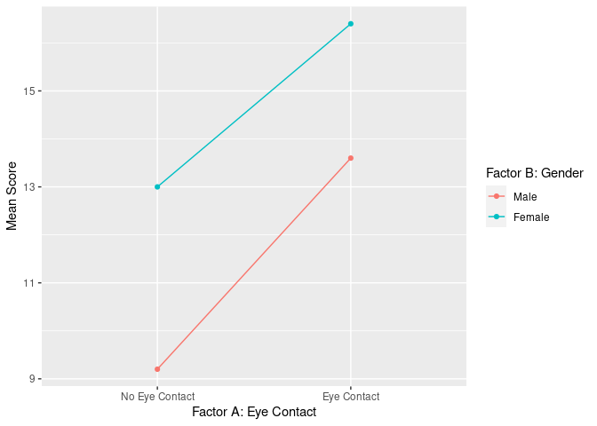

```r
library(ggplot2)
library(plotly)

EyeContact %<>% group_by(contact,gender)

EyeContact$gender %<>% as.factor
EyeContact$contact %<>% as.factor

interaction_plot <- ggplot(data = EyeContact,aes(contact,score,color = gender,group = gender)) +
  stat_summary(fun = mean,geom = "point")+
  stat_summary(fun = mean,geom = "line")+
  ylab("Mean Score")+
  xlab("Factor A: Eye Contact")+
  labs(color = "Factor B: Gender")+
  scale_x_discrete(labels = c("No Eye Contact","Eye Contact"))+
  scale_color_discrete(labels = c("Male","Female"))

interaction_plot
```

In this interaction plot of the Mean Scores on the y-axis, whether the applicant made eye contact or not on the x-axis, and the color of the lines denoting the gender of the officer, we can see there is a possible interaction effect since the lines are not perfectly parallel, but the effect of the interaction probably will not be significant. We need to conduct an F-test in order to test whether the interaction effect is significant or not.

### 3.

```r
anova.table <- function(data,response,factor_a,factor_b){
  factor_a_levels <- data %>% extract2(factor_a) %>% unique %>% length
  factor_b_levels <- data %>% extract2(factor_b) %>% unique %>% length


 first_col_means <- c(1:factor_a_levels) %>% map2_dbl(rep(1,factor_a_levels),~data %>% filter(!!as.symbol(factor_a) == .x & !!as.symbol(factor_b) == .y) %>%
                                                           extract2(response) %>% mean)
second_col_means <- c(1:factor_b_levels) %>% map2_dbl(rep(2,factor_b_levels),~data %>% filter(!!as.symbol(factor_a) == .x & !!as.symbol(factor_b) == .y) %>%
                                                           extract2(response) %>% mean)
  factor_level_means <- cbind(first_col_means,second_col_means)

  factor_a_means <- factor_level_means %>% apply(MARGIN = 1,mean)
  factor_b_means <- factor_level_means %>% apply(MARGIN = 2,mean)

 a <- factor_level_means[1,] %>% length
b <- factor_level_means[,1] %>% length
n <- data %>% filter(!!as.symbol(factor_a) == 1 & !!as.symbol(factor_b) == 1) %>% extract2(response) %>% length
 overall_mean <- data %>% extract2(response) %>% mean



  alpha_hat <- factor_a_means - overall_mean
  beta_hat <- factor_b_means - overall_mean


 first_col_gamma <- c(1:factor_a_levels) %>% map2_dbl(rep(1,factor_b_levels),~factor_level_means[.x,.y] - factor_a_means[.x] -factor_b_means[.y] + overall_mean)
second_col_gamma <- c(1:factor_a_levels) %>% map2_dbl(rep(2,factor_b_levels),~factor_level_means[.x,.y] - factor_a_means[.x] -factor_b_means[.y] + overall_mean)
gamma_hat <- cbind(first_col_gamma,second_col_gamma)

 SSA <- n*b*(sum((alpha_hat)^2))
SSB <- n*a*(sum((beta_hat)^2))
SSAB <- n*sum(gamma_hat^2)



filtered_observations <- c(rep(1,factor_a_levels),rep(2,factor_b_levels)) %>%
  map2(c(1:factor_a_levels,1:factor_b_levels),~data %>% filter(!!as.symbol(factor_a) == .x & !!as.symbol(factor_b) == .y) %>% extract2(response))
filtered_means <- c(factor_level_means[1,1],factor_level_means[1,2],factor_level_means[2,1],factor_level_means[2,2])
SSE <- filtered_observations %>% map2(filtered_means,~sum((.x-.y)^2)) %>% unlist %>% sum


SSTO <- SSA+SSB+SSAB+SSE

df_a <- a-1
df_b <- b-1
df_ab <- (a-1)*(b-1)
df_error <- a*b*(n-1)
df_total <- (n*a*b)-1

MSA <- SSA/df_a
MSB <- SSB/df_b
MSAB <- SSAB/df_ab
MSE <- SSE/df_error

anova_table <- data.frame("SS" = c(SSA,SSB,SSAB,SSE,SSTO),"df" = c(df_a,df_b,df_ab,df_error,df_total),"MS" = c(MSA,MSB,MSAB,MSE,NA))
rownames(anova_table) <- c("Factor A","Factor B","AB Interactions","Error","Total")

return(anova_table)
}


anova_table <- anova.table(EyeContact,"score","contact","gender")
options(knitr.kable.NA = "")
anova_table %>%
   kable() %>%
   kable_styling(bootstrap_options = "striped",full_width = FALSE,position = "center")
```

|  | SS | df | MS |
| --- | --- | --- | --- |
| Factor A | 76.05 | 1 | 76.050 |
| Factor B | 54.45 | 1 | 54.450 |
| AB Interactions | 1.25 | 1 | 1.250 |
| Error | 97.20 | 16 | 6.075 |
| Total | 228.95 | 19 |  |

```r
test_stat <- anova_table["AB Interactions","MS"]/anova_table["Error","MS"]

critical_value <- qf(0.95,1,16)
p_value <- pf(test_stat,1,16,lower.tail = FALSE)

F_test <- data.frame("F_Statistic" = test_stat,"F_Critical_Value" = critical_value,"P_Value" = p_value)
F_test %>%
   kable() %>%
   kable_styling(bootstrap_options = "striped",full_width = FALSE,position = "center")
```

| F_Statistic | F_Critical_Value | P_Value |
| --- | --- | --- |
| 0.2057613 | 4.493999 | 0.656202 |

We need to test whether or not interaction effects are present at a 0.05 significance level. The null hypothesis is $H_0:$ all $\gamma_{ij} = 0$ and the alternative hypothesis is $H_a:$ not all $\gamma_{ij}$ equal to zero. The F-statistic is calculated in the table above. The decision rule is reject the null hypothesis if $F^* > 4.493999$ and fail to reject the null hypothesis if $F^* \leq 4.493999$. From the table above we can see that $0.2057613 \leq 4.493999$ so we fail to reject the null hypothesis and conclude that all $\gamma_{ij} = 0$ at a 0.05 significance level.

## Acknowledgments

I’d like to thank the TA Yejiong Zhu for his explanation of how to find the expectation and variance of alpha hat.

I’d also like to thank Cynthia Huang for her help with finding the variance of gamma hat.